# Proteomics data analysis: cancer example 6x6

Lieven Clement

statOmics, Ghent University (https://statomics.github.io)

# 1 Background

# 2 Data

We first import the peptides.txt file. This is the file that contains your peptide-level intensities. For a MaxQuant search [6], this peptides.txt file can be found by default in the “path_to_raw_files/combined/txt/” folder from the MaxQuant output, with “path_to_raw_files” the folder where raw files were saved. In this tutorial, we will use a MaxQuant peptides file from MaxQuant that can be found in the data tree of the SGA2020 github repository https://github.com/statOmics/SGA2020/tree/data/quantification/cancer .

To import the data we use the `QFeatures` package.

We generate the object peptideRawFile with the path to the peptideRaws.txt file. Using the `grepEcols` function, we find the columns that contain the expression data of the peptideRaws in the peptideRaws.txt file.

```r
library(tidyverse)
library(limma)
library(QFeatures)
library(msqrob2)
library(plotly)

peptidesFile <- "https://raw.githubusercontent.com/statOmics/SGA2020/data/quantification/cancer/peptides3vs3.txt"

ecols <- MSnbase::grepEcols(
  peptidesFile,
  "Intensity ",
  split = "\t")

pe <- readQFeatures(
  table = peptidesFile,
  fnames = 1,
  ecol = ecols,
  name = "peptideRaw", sep="\t")

pe
```

```
## An instance of class QFeatures containing 1 assays:
##  [1] peptideRaw: SummarizedExperiment with 34205 rows and 6 columns
```

```r
pe[["peptideRaw"]]
```

```
## class: SummarizedExperiment
## dim: 34205 6
## metadata(0):
## assays(1): ''
## rownames(34205): AAAAAAAAAAAAAAAGAGAGAK AAAAAAAAAAGAAGGR ...
##   YYWGGQYTWDMAK YYYDGKDYIEFNK
## rowData names(38): Sequence Proteins ... Best.MS.MS
##   Oxidation..M..site.IDs
## colnames(6): Intensity.OR.01 Intensity.OR.04 ... Intensity.PD.03
##   Intensity.PD.04
## colData names(0):
```

We will make use from data wrangling functionalities from the tidyverse package. The %>% operator allows us to pipe the output of one function to the next function.

```r
colData(pe)$outcome <- substr(
  colnames(pe[["peptideRaw"]]),
  11,
  12) %>%
  unlist %>%
  as.factor
```

We calculate how many non zero intensities we have per peptide and this will be useful for filtering.

```r
rowData(pe[["peptideRaw"]])$nNonZero <- rowSums(assay(pe[["peptideRaw"]]) > 0)
```

Peptides with zero intensities are missing peptides and should be represent with a `NA` value rather than `0`.

```r
pe <- zeroIsNA(pe, "peptideRaw") # convert 0 to NA
```

## 2.1 Data exploration

We can inspect the missingness in our data with the `plotNA()` function provided with `MSnbase`. 44% of all peptide intensities are missing and for some peptides we do not even measure a signal in any sample. The missingness is similar across samples.

[figure not shown]

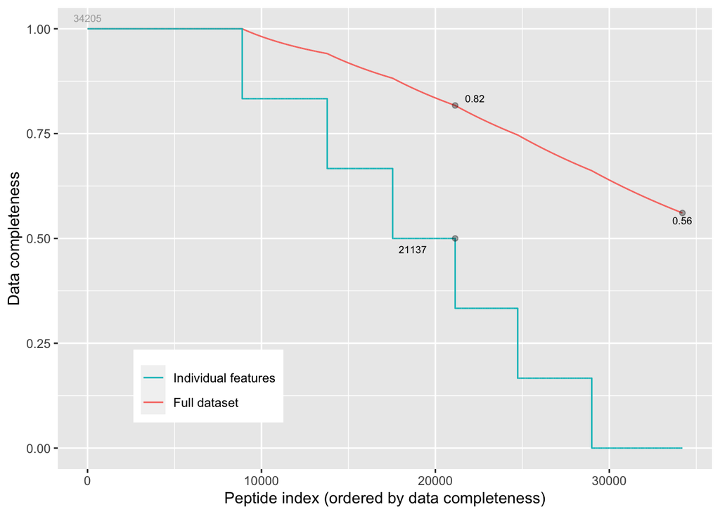

```r
MSnbase::plotNA(assay(pe[["peptideRaw"]])) +
  xlab("Peptide index (ordered by data completeness)")
```

# 3 Preprocessing

This section preforms standard preprocessing for the peptide data. This include log transformation, filtering and summarisation of the data.

## 3.1 Log transform the data

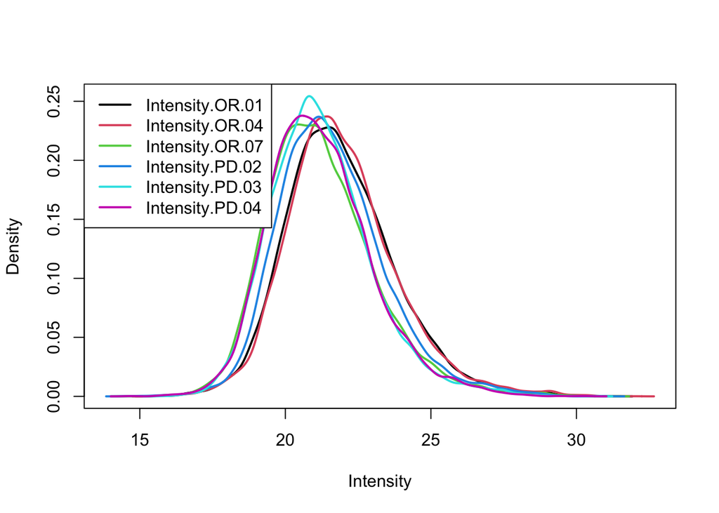

```r
pe <- logTransform(pe, base = 2, i = "peptideRaw", name = "peptideLog")
limma::plotDensities(assay(pe[["peptideLog"]]))
```

## 3.2 Filtering

### 3.2.1 Handling overlapping protein groups

In our approach a peptide can map to multiple proteins, as long as there is none of these proteins present in a smaller subgroup.

```r
pe[["peptideLog"]] <-
 pe[["peptideLog"]][rowData(pe[["peptideLog"]])$Proteins
 %in% smallestUniqueGroups(rowData(pe[["peptideLog"]])$Proteins),]
```

### 3.2.2 Remove reverse sequences (decoys) and contaminants

We now remove the contaminants, peptides that map to decoy sequences, and proteins which were only identified by peptides with modifications.

```r
pe[["peptideLog"]] <- pe[["peptideLog"]][rowData(pe[["peptideLog"]])$Reverse != "+", ]
pe[["peptideLog"]] <- pe[["peptideLog"]][rowData(pe[["peptideLog"]])$
Contaminant != "+", ]
```

### 3.2.3 Remove peptides of proteins that were only identified with modified peptides

I will skip this step for the moment. Large protein groups file needed for this.

### 3.2.4 Drop peptides that were only identified in one sample

We keep peptides that were observed at last twice.

```r
pe[["peptideLog"]] <- pe[["peptideLog"]][rowData(pe[["peptideLog"]])$nNonZero >= 2, ]
nrow(pe[["peptideLog"]])
```

```
## [1] 22413
```

We keep 22413 peptides after filtering.

## 3.3 Quantile normalize the data

```r
pe <- normalize(pe, i = "peptideLog", method = "quantiles", name = "peptideNorm")
```

## 3.4 Explore quantile normalized data

After quantile normalisation the density curves for all samples coincide.

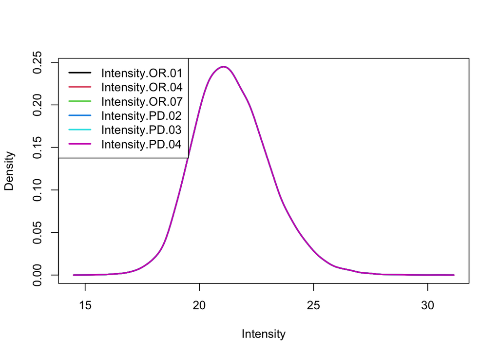

```r
limma::plotDensities(assay(pe[["peptideNorm"]]))
```

This is more clearly seen is a boxplot.

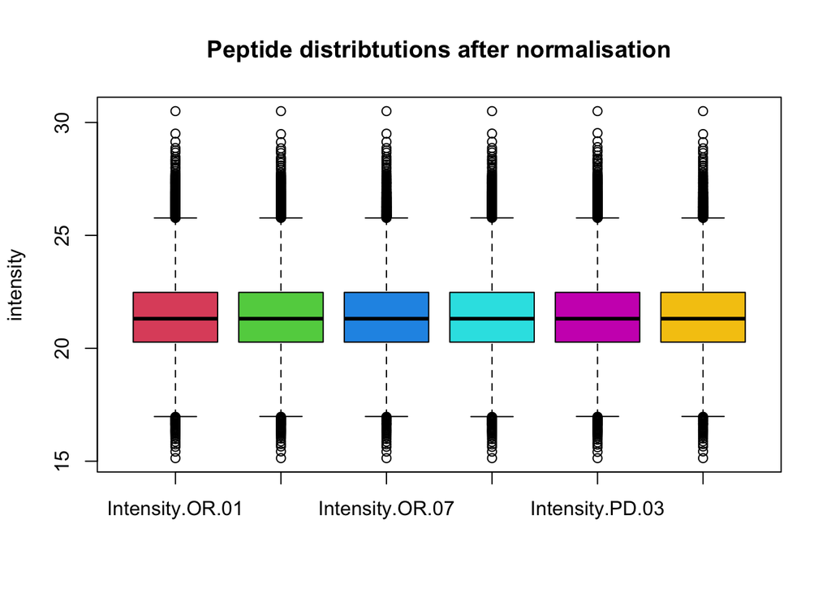

```r
boxplot(assay(pe[["peptideNorm"]]), col = palette()[-1],
       main = "Peptide distribtutions after normalisation", ylab = "intensity")
```

We can visualize our data using a Multi Dimensional Scaling plot, eg. as provided by the `limma` package.

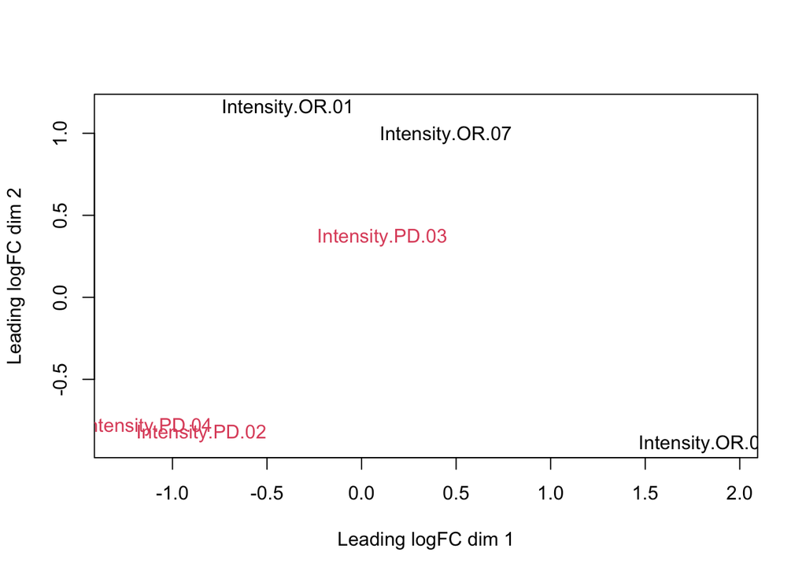

```r
limma::plotMDS(assay(pe[["peptideNorm"]]), col = as.numeric(colData(pe)$outcome))
```

The first axis in the plot is showing the leading log fold changes (differences on the log scale) between the samples.

## 3.5 Summarization to protein level

We use robust summarization in aggregateFeatures. This is the default workflow of aggregateFeatures so you do not have to specifiy the argument `fun`. However, because we compare methods we have included the `fun` argument to show the summarization method explicitely.

```r
pe <- aggregateFeatures(pe,
 i = "peptideNorm",
 fcol = "Proteins",
 na.rm = TRUE,
 name = "proteinRobust",
 fun = MsCoreUtils::robustSummary)
```

```
## Your quantitative and row data contain missing values. Please read the
## relevant section(s) in the aggregateFeatures manual page regarding the
## effects of missing values on data aggregation.
```

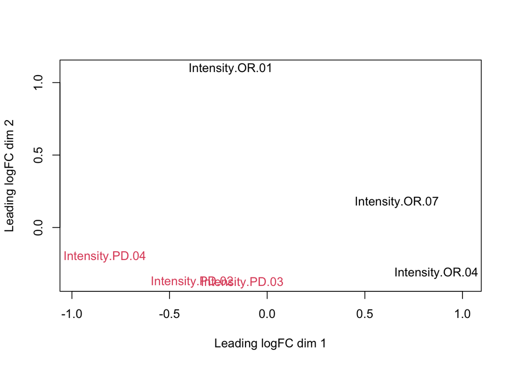

```r
plotMDS(assay(pe[["proteinRobust"]]), col = as.numeric(colData(pe)$outcome))
```

# 4 Data Analysis

## 4.1 Estimation

We model the protein level expression values using `msqrob`. By default `msqrob2` estimates the model parameters using robust regression.

```r
pe <- msqrob(object = pe, i = "proteinRobust", formula = ~outcome)
```

## 4.2 Inference

First, we extract the parameter names of the model.

```r
getCoef(rowData(pe[["proteinRobust"]])$msqrobModels[[1]])
```

```
## (Intercept)   outcomePD
##  19.8230219   0.8505129
```

Spike-in outcome a is the reference class. So the mean log2 expression for samples from outcome a is ‘(Intercept). The mean log2 expression for samples from outcome B is’(Intercept)+outcomePD’. Hence, the average log2 fold change between outcome b and outcome a is modelled using the parameter ‘outcomePD’. Thus, we assess the contrast ‘outcomePD=0’ with our statistical test.

```r
L <- makeContrast("outcomePD=0", parameterNames = c("outcomePD"))
pe <- hypothesisTest(object = pe, i = "proteinRobust", contrast = L)
```

## 4.3 Plots

### 4.3.1 Volcano-plot

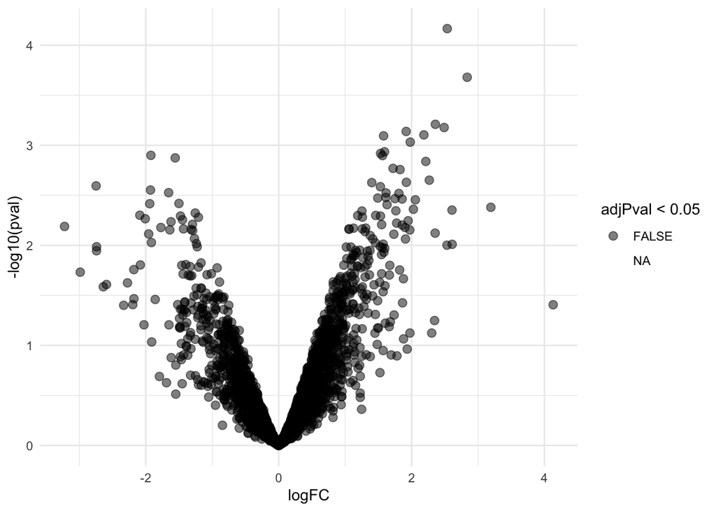

```r
volcano <- ggplot(rowData(pe[["proteinRobust"]])$outcomePD,
                 aes(x = logFC, y = -log10(pval), color = adjPval < 0.05)) +
 geom_point(cex = 2.5) +
 scale_color_manual(values = alpha(c("black", "red"), 0.5)) + theme_minimal()
volcano
```